# Univariate LIBS Calibration curve

Komi Messan

March 5, 2019

# Analysis on Lead data

## Handling the negative intensities

It is noteworthy to point out that several intensities values are negative due to noises in the data. To process this data, all negative intensities values were treating as missing values in the remaining of the analysis. Thus we have baseline of 0 for the intensities value.

The average of each of the nine shots were taken by only considering the positive values using a pre-defined function and also a function to calculate all Rsquare values

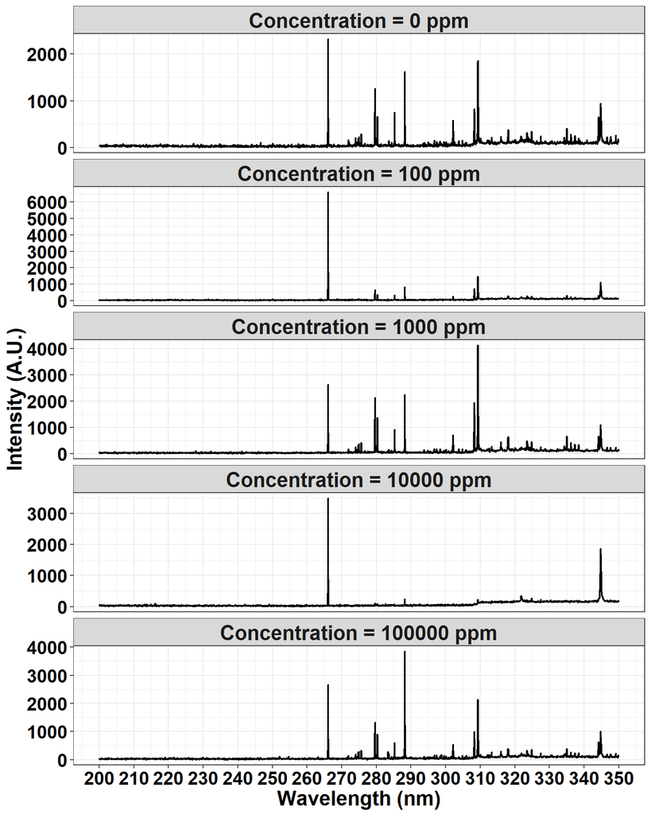

## Calibration curve for lead at 280.2 nm

From the access to the National Institute of Standards and Technology (NIST) atomic emission spectrum database which can be found here [here](https://physics.nist.gov/PhysRefData/Handbook), the higher intensity of lead (Pb) occurs at 280.1995 which is approximately equal to 280.2 thus we select 280.2 for our univariate analysis.

```
##
## Call:
## lm(formula = Mean_I ~ Concentration, data = lead_uni_data)
##
## Residuals:
##       1       2       3       4       5
## -21.940   5.719  98.213 -90.004   8.013
##
## Coefficients:
##                Estimate Std. Error t value Pr(>|t|)
## (Intercept)   1.289e+02  4.021e+01   3.207   0.0491 *
## Concentration 2.182e-03  8.946e-04   2.439   0.0926 .
## ---
## Signif. codes:  0 '***' 0.001 '**' 0.01 '*' 0.05 '.' 0.1 ' ' 1
##
## Residual standard error: 78.16 on 3 degrees of freedom
## Multiple R-squared:  0.6647, Adjusted R-squared:  0.5529
## F-statistic: 5.947 on 1 and 3 DF,  p-value: 0.09261
```

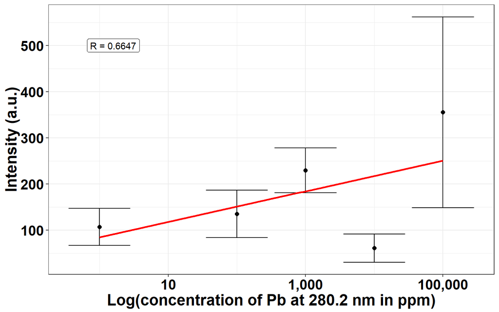

# Analysis on zinc data

## Handling the negative intensities

Now we take the average of all the nine positive shots by considering only the positive intensities

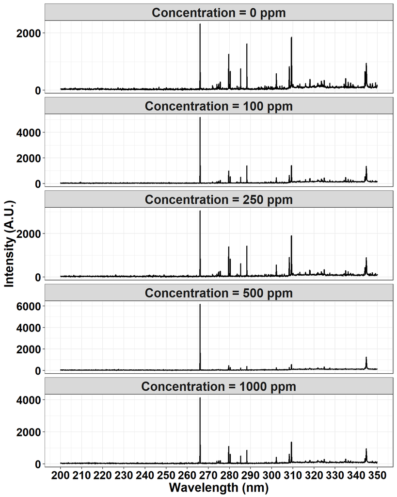

## Calibration curve for zinc at 213.85735 nm

From the access to the National Institute of Standards and Technology (NIST) atomic emission spectrum database, the higher intensity of zinc (Zn) occurs at 213.85735 which is approximately equal to 213.8 thus we select 213.8 for our univariate analysis.

```
##
## Call:
## lm(formula = Mean_I ~ Concentration, data = zinc_uni_data)
##
## Residuals:
##       1       2       3       4       5
##  6.8378  0.7735 -5.7229 -6.4835  4.5951
##
## Coefficients:
##                Estimate Std. Error t value Pr(>|t|)
## (Intercept)   15.962226   4.449376   3.588   0.0371 *
## Concentration  0.020643   0.008651   2.386   0.0971 .
## ---
## Signif. codes:  0 '***' 0.001 '**' 0.01 '*' 0.05 '.' 0.1 ' ' 1
##
## Residual standard error: 6.91 on 3 degrees of freedom
## Multiple R-squared:  0.6549, Adjusted R-squared:  0.5399
## F-statistic: 5.693 on 1 and 3 DF,  p-value: 0.09709
```

[figure not shown]

# Analysis on Antimony (Sb) data

## Handling the negative intensities

Now we take the average of all the nine positive shots by considering only the positive intensities

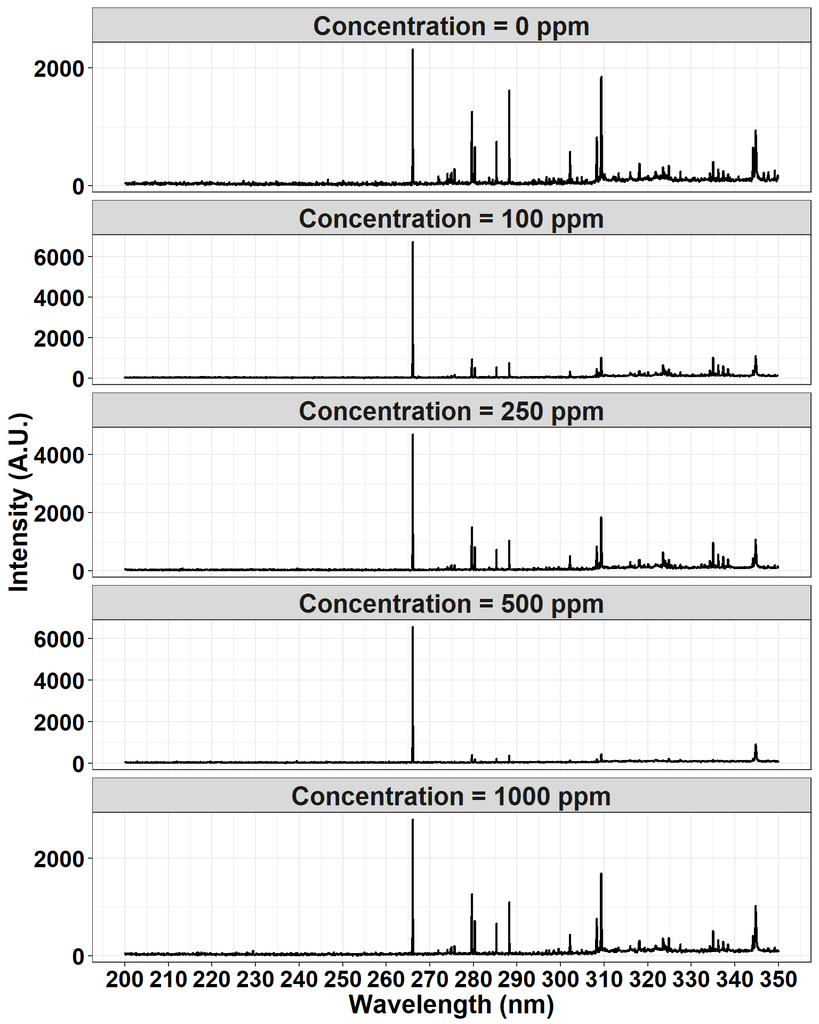

## Calibration curve for antimony at 276.9931 nm

From the access to the National Institute of Standards and Technology (NIST) atomic emission spectrum database, the higher intensity of Antimony (Sb) occurs at 276.9931 which is approximately equal to 276.9 thus we select 276.9 for our univariate analysis.

```
##
## Call:
## lm(formula = Mean_I ~ Concentration, data = antimony_uni_data)
##
## Residuals:
##      1      2      3      4      5
## -1.037  1.585  4.101 -6.928  2.281
##
## Coefficients:
##                Estimate Std. Error t value Pr(>|t|)
## (Intercept)   30.203945   3.189278   9.470   0.0025 **
## Concentration  0.032115   0.006201   5.179   0.0140 *
## ---
## Signif. codes:  0 '***' 0.001 '**' 0.01 '*' 0.05 '.' 0.1 ' ' 1
##
## Residual standard error: 4.953 on 3 degrees of freedom
## Multiple R-squared:  0.8994, Adjusted R-squared:  0.8659
## F-statistic: 26.82 on 1 and 3 DF,  p-value: 0.01397
```

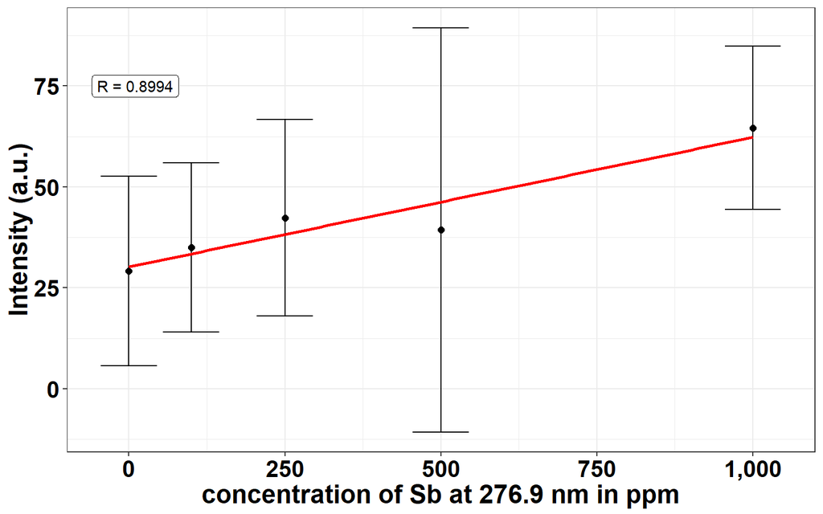

# Analysis on Tungsten (W) data

## Handling the negative intensities

Now we take the average of all the nine positive shots by considering only the positive intensities

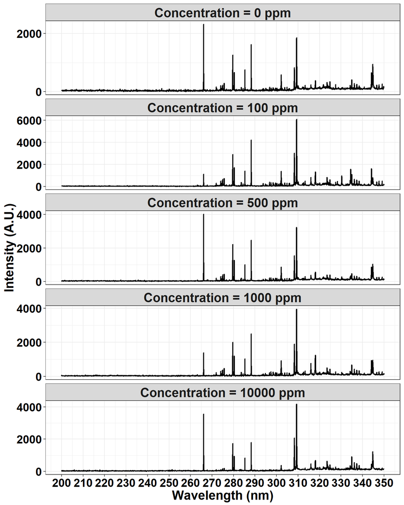

## Calibration curve for tungsten at 212.1576 nm

From the access to the National Institute of Standards and Technology (NIST) atomic emission spectrum database, the higher intensity of Tungsten (W) occurs at 212.1576 which is approximately equal to 212.1 thus we select 212.1 nm for our univariate analysis.

```
##
## Call:
## lm(formula = Mean_I ~ Concentration, data = tungsten_uni_data)
##
## Residuals:
##      1      2      3      4      5
## -8.657  0.248 -2.065 11.524 -1.051
##
## Coefficients:
##                Estimate Std. Error t value Pr(>|t|)
## (Intercept)   3.215e+01  4.400e+00   7.308  0.00529 **
## Concentration 3.490e-03  9.776e-04   3.570  0.03756 *
## ---
## Signif. codes:  0 '***' 0.001 '**' 0.01 '*' 0.05 '.' 0.1 ' ' 1
##
## Residual standard error: 8.429 on 3 degrees of freedom
## Multiple R-squared:  0.8094, Adjusted R-squared:  0.7459
## F-statistic: 12.74 on 1 and 3 DF,  p-value: 0.03756
```

[figure not shown]